# Shareclass Activity 2020

Adrian D. Garcia

January 2021

# Intro

## Getting Started

- != Fund of funds: Yes
- != Morningstar Category: Money Market - Non-40 ACT
- != Morningstar Category: Money Market - Taxable
- != Morningstar Category: Money Market - Taxfree

56,284 rows, 36 columns

Added column *Obsolete* to indicate if share class is in existence or obsolete. I assume a blank *Obsolete..Date* means the share class still exists.

Also added *Inception_Year* and *Obsolete_Year* because these variables are used below.

48,520 rows, 41 columns

```r
library(tidyverse) #For Data Analysis
library(lubridate) #For working with dates
library(DT) #For visualizing tables


Full <- read_csv("data_combined.csv",
                 guess_max = 20000) %>%
  rename_all(make.names) %>%
  mutate(
    Inception_Year = year(Inception..Date),
    Obsolete_Year = year(Obsolete..Date),
    Obsolete =
           case_when(
             !is.na(Obsolete..Date) ~ "Obsolete",
             TRUE ~ "Exists"
           )) %>%
  filter(Share.Class.Type != "Load Waived" |
           is.na(Share.Class.Type)) %>%
  filter((Inception_Year != Obsolete_Year) |
             is.na(Obsolete_Year) |
             is.na(Inception_Year)) %>%
  filter(Inception_Year != 2021 |
           Obsolete_Year != 2021)
```

# Overview

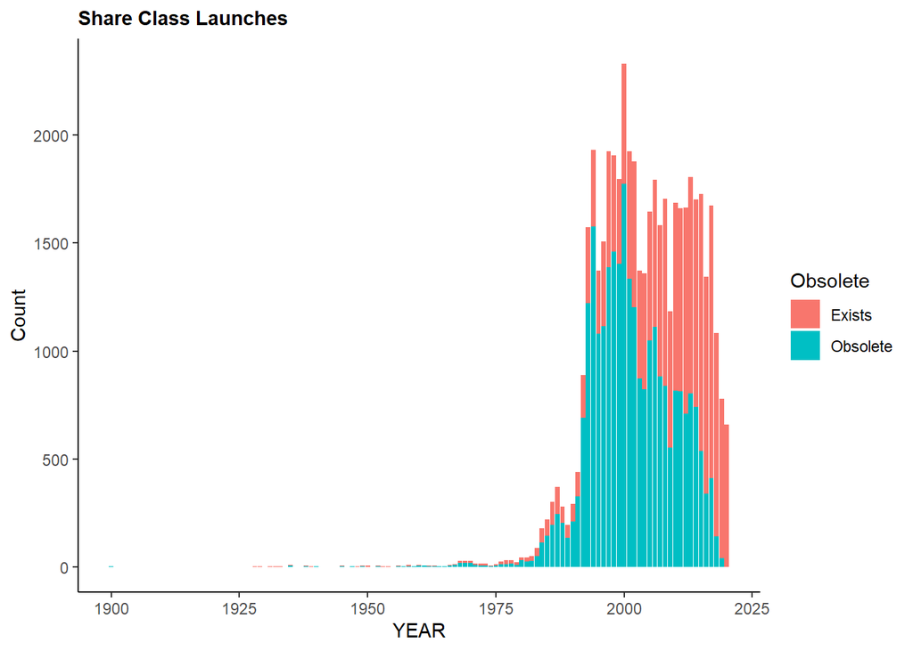

## Net Count

There was a large drop off in launches in 2020 compared to recent years. However it appears rationalization continued at roughly the same levels as recent years.

Of 48,520 fund share classes examined there are inception dates missing for 83.

```r
#A function to count the number of share classes either created or liquidated each year

Year_Count <- function(colz){
 Full %>%
    group_by_at(colz) %>%
    summarise(Count = n(), .groups = "drop") %>%
    arrange(desc(.[[1]]))
    }


inception_year <- Year_Count(colz = c("Inception_Year")) #Tallys share classes by year created
obsolete_year <- Year_Count(colz = c("Obsolete_Year")) #Tallys share classes by year liquidated

merge_type <- Year_Count(colz = c("Obsolete_Year", "Obsolete..Type")) #Tallys share classes by year liquidated and liquidation type


#Counts the net number of share classes created/cut

Net_Count <- full_join(inception_year, obsolete_year, by = c("Inception_Year" = "Obsolete_Year"),
                       suffix = c("_inception", "_obsolete")) %>%
  rename(Year = Inception_Year) %>%
  group_by(Year) %>%
  mutate(Net_Count = sum(Count_inception, -Count_obsolete, na.rm = TRUE))
```

|  | Year | Share_Classes_Launched | Share_Classes_Cut | Net_Count |
| --- | --- | --- | --- | --- |
| 1 | 2020 | 661 | 1365 | -704 |
| 2 | 2019 | 780 | 1359 | -579 |
| 3 | 2018 | 1083 | 1679 | -596 |
| 4 | 2017 | 1673 | 1577 | 96 |
| 5 | 2016 | 1345 | 1326 | 19 |
| 6 | 2015 | 1725 | 1102 | 623 |
| 7 | 2014 | 1701 | 766 | 935 |
| 8 | 2013 | 1806 | 918 | 888 |
| 9 | 2012 | 1664 | 1052 | 612 |
| 10 | 2011 | 1661 | 1225 | 436 |

[output cut: 85 more lines]

## By Month

```r
Obsolete_Month <- function(x){
  Full %>%
  filter(Obsolete_Year == x) %>%
  mutate(Month = month(Obsolete..Date)) %>%
  group_by(Month) %>%
  count(name = paste("Obsolete_", x, sep = "") )
}


Years <- c("2018", "2019", "2020")

By_Month_Obsolete <- Years %>%
  map(Obsolete_Month) %>%
  reduce(full_join, by = "Month")
```

Share Class Liquidations & Mergers

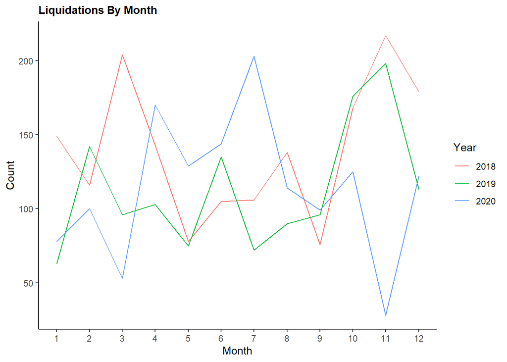

Share Class Launches by Month

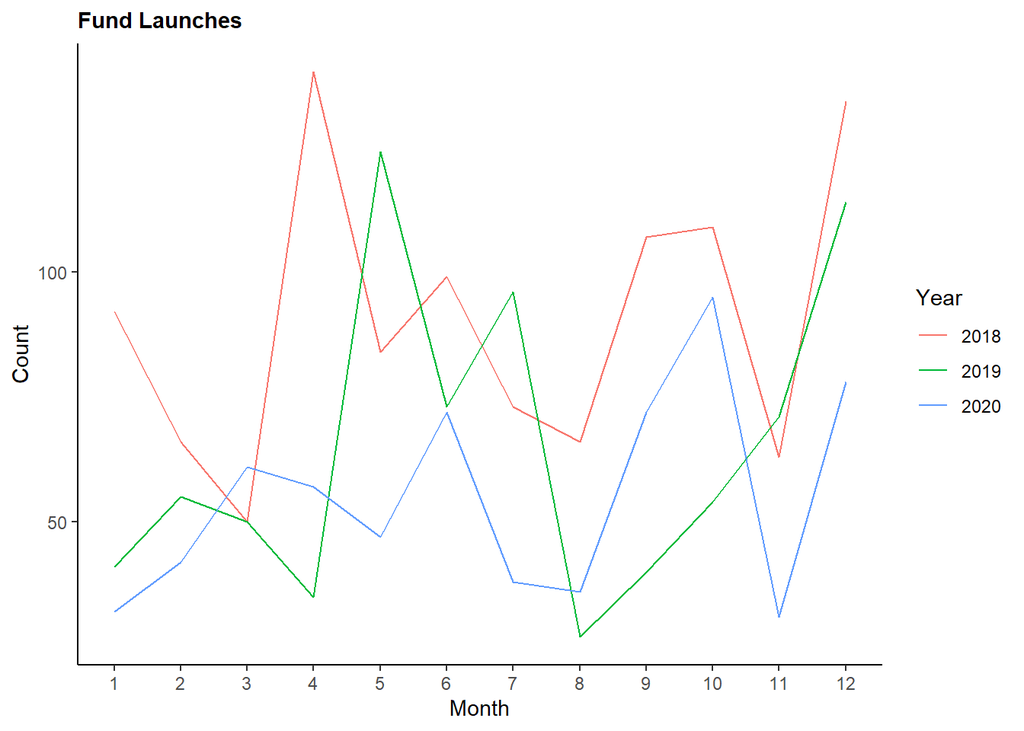

```r
By_Month_Inception %>%
  pivot_longer(
    !Month,
    names_to = "Year",
    values_to = "Count"
  ) %>%
  mutate(Year = str_replace(Year, "Inception_", "")) %>%
  ggplot(data = . , aes(x = Month, y = Count, color = Year)) +
  geom_line() +
  ggtitle("Fund Launches") +
  ylab("Count") +
  xlab("Month") +
  scale_x_continuous(breaks = seq(1, 12, by = 1)) +
  theme_classic() +
  theme(plot.title = element_text(size = 11, face = "bold"))
```

## Liquidations

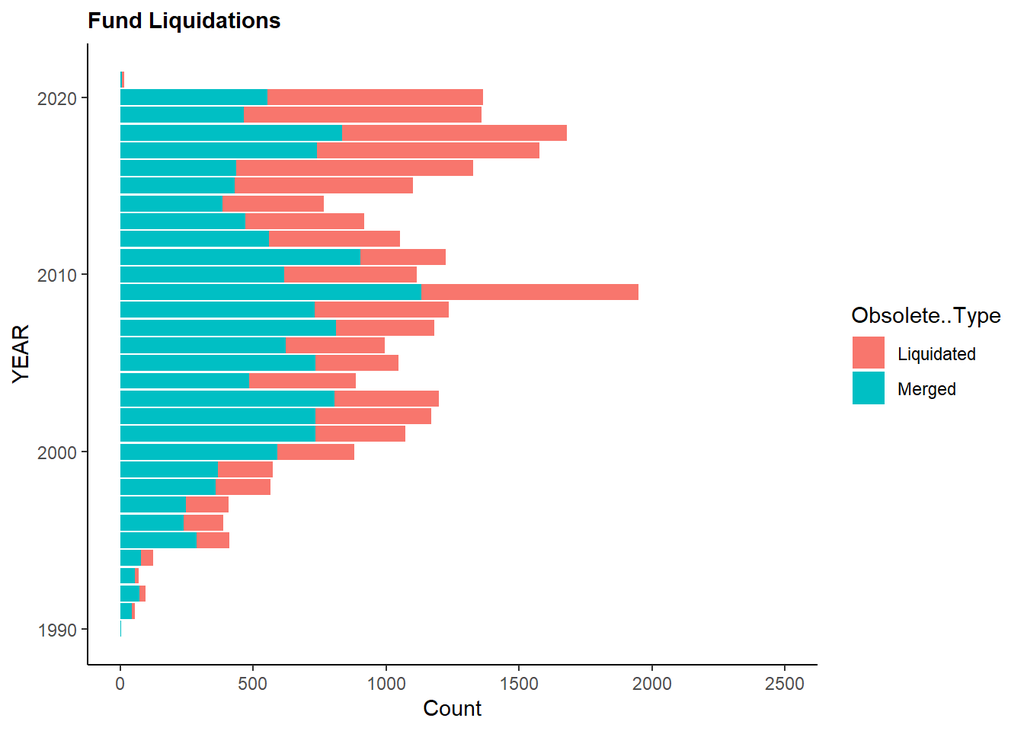

|  | Obsolete_Year | Liquidated | Merged |
| --- | --- | --- | --- |
| 1 | 2021 | 8 | 5 |
| 2 | 2020 | 811 | 554 |
| 3 | 2019 | 895 | 464 |
| 4 | 2018 | 845 | 834 |
| 5 | 2017 | 837 | 740 |
| 6 | 2016 | 890 | 436 |
| 7 | 2015 | 671 | 431 |
| 8 | 2014 | 382 | 384 |
| 9 | 2013 | 447 | 471 |
| 10 | 2012 | 492 | 560 |

[output cut: 22 more lines]

## New Funds

The data from Morningstar is at the share class level. This is a method to look at launches at the fund level.

```r
#This looks at when a fund's oldest share class was created
#This assumes that the oldest share class's inception date is equal to the fund's creation date

New_Funds <- Full %>%
  filter(Oldest..Share.Class == "Yes") %>%
  group_by(Inception_Year, Index..Fund) %>%
  summarise(Count = n(), .groups = "drop") %>%
  mutate(
    Pct_Change = round(
      ((Count/lag(Count) - 1) * 100),
      1
    )) %>%
  arrange(desc(Inception_Year))
```

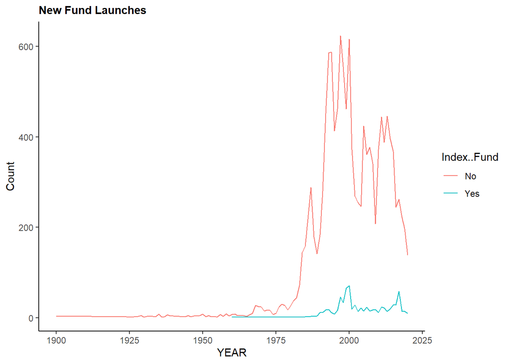

|  | Inception_Year | Active | Passive | total |
| --- | --- | --- | --- | --- |
| 1 | 2020 | 138 | 10 | 148 |
| 2 | 2019 | 197 | 14 | 211 |
| 3 | 2018 | 222 | 14 | 236 |
| 4 | 2017 | 262 | 58 | 320 |
| 5 | 2016 | 245 | 28 | 273 |
| 6 | 2015 | 368 | 28 | 396 |
| 7 | 2014 | 396 | 20 | 416 |
| 8 | 2013 | 446 | 14 | 460 |
| 9 | 2012 | 388 | 21 | 409 |
| 10 | 2011 | 444 | 24 | 468 |

[output cut: 84 more lines]

## New Funds (Alternative)

The method above uses the inception date of the *Oldest..Share.Class* as a proxy for when a fund was created. This method uses *FundId*.

The oldest inception date related to a *FundID* is a proxy for when the fund was created. Or the oldest obsolete date related to a a *FundID* (with no active share classes) is likely when that fund was liquidated/merged.

There were some cases identified in the data where a FundID had no corresponding *Oldest..Share.Class*. This could be an error or signal that a fund’s oldest share class is not captured in the data from Morningstar.

The results for 2020 ended up equal using the method above.

This method shows there were 15,825 funds in 2020 vs 15,677 in 2019 – a change of 148 funds. This method shows there were 15,464 in 2018 – a change of 213 funds.

# Companies

To look at which firms cut or added share classes I first clean up the company names with Branding.Names.Mod.

```r
company_change <- Full %>%
  mutate(
    Branding.Name.Mod =
    case_when(
      grepl("State Street", Branding.Name) ~ "State Street",
      grepl("TIAA", Branding.Name) ~ "TIAA/Nuveen",
      grepl("Nuveen", Branding.Name) ~ "TIAA/Nuveen",
      grepl("Eaton Vance", Branding.Name) ~ "Eaton Vance/Calvert",
      grepl("Calvert", Branding.Name) ~ "Eaton Vance/Calvert",
      grepl("iShares", Branding.Name) ~ "iShares/BlackRock",
      grepl("BlackRock", Branding.Name) ~ "iShares/BlackRock",
      grepl("PowerShares", Branding.Name) ~ "PowerShares/Invesco",
      grepl("Invesco", Branding.Name) ~ "PowerShares/Invesco",
      grepl("DWS$", Branding.Name) ~ "DWS/Xtrackers",
      grepl("Xtrackers", Branding.Name) ~ "DWS/Xtrackers",
      TRUE ~ Branding.Name))

company_count <- function(x, colz){
  company_change %>%
    group_by_at(colz) %>%
    summarise(Count = n()) %>%
    ungroup() %>%
    arrange(desc(.[[2]]))
   }

comp_inception <- company_count(colz = c("Branding.Name.Mod", "Inception_Year"))
comp_obsolete <- company_count(colz = c("Branding.Name.Mod", "Obsolete_Year"))
comp_new_funds <- company_count(colz = c("Branding.Name.Mod", "Inception_Year", "Oldest..Share.Class")) %>%
  filter(Oldest..Share.Class == "Yes")
comp_old_funds <- company_count(colz = c("Branding.Name.Mod", "Obsolete_Year", "Oldest..Share.Class")) %>%
  filter(Oldest..Share.Class == "Yes")
comp_rank <- function(x){
  x %>%  filter(.[[2]] == "2020") %>%
  mutate(Rank = rank(-Count)) %>%
  filter(Rank <=20) %>%
    arrange(Rank)
}

top_cutters <- comp_rank(comp_obsolete)
top_old_cutters <-  comp_rank(comp_old_funds)

top_launchers <- comp_rank(comp_inception)
top_new_launchers <- comp_rank(comp_new_funds)
```

## Top Launchers

(Share Class)

|  | Branding.Name.Mod | Inception_Year | Count | Rank |
| --- | --- | --- | --- | --- |
| 1 | American Funds | 2020 | 77 | 1 |
| 2 | T. Rowe Price | 2020 | 37 | 2 |
| 3 | Fidelity | 2020 | 31 | 3 |
| 4 | iShares/BlackRock | 2020 | 30 | 4 |
| 5 | Lord Abbett | 2020 | 29 | 5 |
| 6 | Victory Capital | 2020 | 26 | 6 |
| 7 | Natixis | 2020 | 22 | 7 |
| 8 | Morgan Stanley | 2020 | 21 | 8 |
| 9 | New York Life | 2020 | 16 | 9 |
| 10 | Goldman Sachs | 2020 | 15 | 10 |

[output cut: 13 more lines]

## Top New Fund Launchers

(Oldest Share Class)

|  | Branding.Name.Mod | Inception_Year | Oldest..Share.Class | Count | Rank |
| --- | --- | --- | --- | --- | --- |
| 1 | Fidelity | 2020 | Yes | 14 | 1 |
| 2 | iShares/BlackRock | 2020 | Yes | 10 | 2 |
| 3 | Morgan Stanley | 2020 | Yes | 5 | 3 |
| 4 | Natixis | 2020 | Yes | 4 | 5 |
| 5 | T. Rowe Price | 2020 | Yes | 4 | 5 |
| 6 | WCM Investment Management | 2020 | Yes | 4 | 5 |
| 7 | American Beacon | 2020 | Yes | 3 | 10 |
| 8 | Ashmore | 2020 | Yes | 3 | 10 |
| 9 | Eaton Vance/Calvert | 2020 | Yes | 3 | 10 |
| 10 | Fisher Investments | 2020 | Yes | 3 | 10 |

[output cut: 3 more lines]

## Top Cutters

(Share Class)

|  | Branding.Name.Mod | Obsolete_Year | Count | Rank |
| --- | --- | --- | --- | --- |
| 1 | PowerShares/Invesco | 2020 | 152 | 1 |
| 2 | Columbia Threadneedle | 2020 | 79 | 2 |
| 3 | Allianz Global Investors | 2020 | 47 | 3 |
| 4 | American Century | 2020 | 38 | 4 |
| 5 | John Hancock | 2020 | 37 | 5 |
| 6 | Jackson National | 2020 | 36 | 6 |
| 7 | PGIM Investments | 2020 | 30 | 7 |
| 8 | American Beacon | 2020 | 29 | 8 |
| 9 | TIAA/Nuveen | 2020 | 28 | 9 |
| 10 | Voya | 2020 | 27 | 10 |

[output cut: 10 more lines]

## Top Fund Cutters

(Oldest Share Class)

|  | Branding.Name.Mod | Obsolete_Year | Oldest..Share.Class | Count | Rank |
| --- | --- | --- | --- | --- | --- |
| 1 | PowerShares/Invesco | 2020 | Yes | 26 | 1 |
| 2 | Jackson National | 2020 | Yes | 18 | 2 |
| 3 | Allianz Global Investors | 2020 | Yes | 14 | 3 |
| 4 | Hartford Investments | 2020 | Yes | 8 | 4.5 |
| 5 | Wells Fargo | 2020 | Yes | 8 | 4.5 |
| 6 | American Beacon | 2020 | Yes | 7 | 8 |
| 7 | American Century | 2020 | Yes | 7 | 8 |
| 8 | ICON | 2020 | Yes | 7 | 8 |
| 9 | Mutual of America | 2020 | Yes | 7 | 8 |
| 10 | TIAA/Nuveen | 2020 | Yes | 7 | 8 |

[output cut: 11 more lines]

# Share Class Overview

```r
simp_count <- function(x, colz){
  Full %>%
    group_by_at(colz) %>%
    count(name = "Count")
  }

share_class_add_count <- simp_count(colz = c("Inception_Year", "Share.Class.Type"))
```

From Morningstar Direct

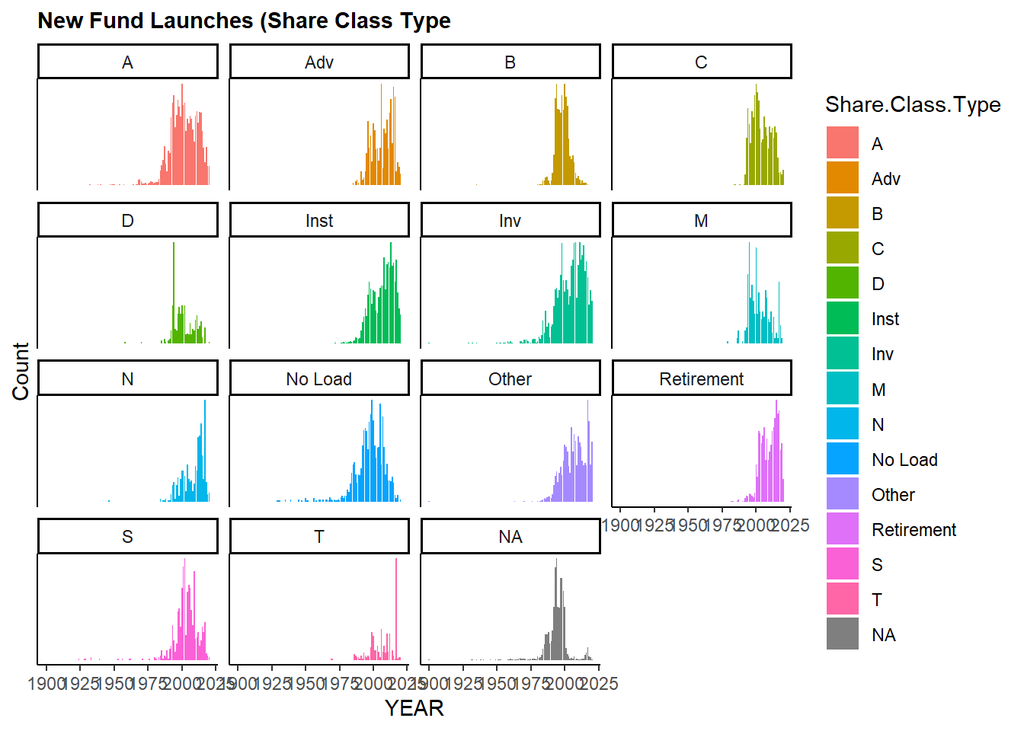

## 2020

|  | Inception_Year | Share.Class.Type | Count |
| --- | --- | --- | --- |
| 1 | 2020 | Other | 190 |
| 2 | 2020 | Inst | 186 |
| 3 | 2020 | Retirement | 92 |
| 4 | 2020 | A | 69 |
| 5 | 2020 | C | 63 |
| 6 | 2020 | Inv | 35 |
| 7 | 2020 | Adv | 11 |
| 8 | 2020 | N | 6 |
| 9 | 2020 | No Load | 2 |
| 10 | 2020 | S | 2 |

[output cut: 3 more lines]